# 🛡️ 1 Flanders EE Resilience Analysis — Network-Based Assessment

🔬 **What**: We replicate and extend the Berlin ecosystem resilience study (Noak et al., 2025) for Flanders — measuring coherence, connectivity, diversity, and attack tolerance of the investor co-investment network. Berlin study covers 2010–2022.  
📊 **Data**: 1,652 funding records from Dealroom (1,536) + BAN (116) → 826 unique startups, 724 unique investors. Private co-investment only (Noak-compatible). Sequenza (GUO-switches) and NBB (shareholding) are deliberately excluded — they capture ownership relationships, not co-investment rounds.  
🏗️ **Depends on**: Notebook 0 v2 (Data Preparation) — run that first to populate `funding_network`  
🎯 **Key change vs v1**: O&O&I + KMOGS excluded from network (public subsidies ≠ co-investment). VLAIO-effect measured separately in Notebook 1b.  
📖 **Suite overview**: Notebook 00 — Introduction  
📝 **Companion**: Notebook 1b (VLAIO-effect Analysis) — measures public funding impact (O&O&I + KMOGS) as node attributes on this network  
📎 **Reference**: Noak, T., Kuckertz, A., & Breithaupt, P. (2025). *The resilience of entrepreneurial ecosystems: A network analysis of the Berlin startup ecosystem.* Small Business Economics.

```
Total investment records: 1652
Year range: 2011 - 2026

By source:
          records  startups
source
ban           116        91
dealroom     1536       775

Unique startups: 826
Unique investors: 724

Industries coverage: 1,505 / 1,652 (91%)
```

```
Clean records with investors and dates: 1652
Year range: 2011 - 2026

Investments by year:
year
2011      1
2013      2
2014     47
2015     78
2016    121
2017     96
2018    145
2019    179
2020    186
2021    203
2022    185
2023    144
2024    124
2025    120
2026     21
dtype: int64

Unique startups: 826
Total investor-startup connections: 2324
```

```
  ⚠️  4 names appear as both startup AND investor: {'Idalko', 'EnergyVision', 'Aikido Security', 'Winwinner'}
      Removing from investor_set to preserve startup classification.

  ⚠️  Removed 'unknown' placeholder (undisclosed Dealroom rounds).
      Impact: -199 bipartite edges, -275 projected co-investment ties, -32 peripheral investors.

Bipartite network created:
  Total nodes: 1545
  - Startups: 826
  - Investors: 719
  Total edges (investments): 1980

Top 10 most active investors:
  Start it @KBC: 296 investments
  imec.istart: 112 investments
  BAN Vlaanderen: 91 investments
  Ghent University: 64 investments
  PMV: 62 investments
  KU Leuven: 44 investments
  imec: 36 investments
  European Innovation Council: 32 investments
  VLAIO- Team Bedrijfstrajecten Crossroads France-Wallonie-Vlaanderen: 31 investments
  EIT Health: 25 investments
```

```
Investor network (projection):
  Nodes (investors): 719
  Edges (co-investments): 4037
  Network density: 0.0156
  Network is NOT connected
  Number of connected components: 89
  Largest component size: 600 nodes (83.4%)

  Using largest connected component for analysis:
    Nodes: 600
    Edges: 3909
```

```
Startups in dataset: 826
  Belgian:     825
  Non-Belgian: 1
  Names: {'Climate Camp'}

================================================================================
BRIDGE ANALYSIS
================================================================================

  Co-investment edges from Belgian startups:     4,037
  Co-investment edges from non-Belgian startups: 0
  Artificial edges (ONLY from non-Belgian):      0

  ✅ No artificial bridges! All non-Belgian co-investment edges also
     exist via Belgian startups. Safe to remove non-Belgian data.

  ✅ All investors also invest in Belgian startups. No investor loss.
```

```
================================================================================
COHERENCE METRICS
================================================================================

1. Average Closeness: 0.3787
   Interpretation: Measures information flow efficiency.
   Higher = faster shock circulation across ecosystem

2. Mean Coreness: 8.8200
   Max k-core: 24
   Interpretation: Strength of network's core vs periphery.
   Higher = strong central hub, potential exclusivity

3. Transitivity (Global Clustering): 0.3077
   Interpretation: Tendency for close-knit investor groups.
   Higher = stable mutual relationships, risk sharing

4. Community Structure:
   Number of communities: 21
   Average community size: 28.57
   Interpretation: Scale of investor clusters.
   Larger = strong internal connections, potential vulnerability

   Communities (by size):
     imec.istart (193)
     PMV (128)
     Pitchdrive (99)
     Asabys Partners (21)
     Notion Capital (19)
     Wim Derkinderen (17)
     European Investment (13)
     Pieter Casneuf (13)
     HTGF (12)
     BNP Paribas Fortis (11)
     YZi Labs (11)
     DSM Venturing (11)
     imec.istart future f (11)
     Spreds (9)
     LeanSquare (6)
     Outpost24 (5)
     RightCrowd (5)
     Piet Opstaele (5)
     Bob Verbeeck (5)
     Freshmen (4)
     Tilleghem (2)
```

```
================================================================================
CONNECTIVITY METRICS
================================================================================

1. Average Path Length: 2.6756
   Interpretation: Communication efficiency between investors.
   Shorter = high interconnectedness, fast shock propagation

2. Average Eccentricity: 4.2350
   Network diameter: 6
   Network radius: 3
   Interpretation: Network's overall reach.
   Higher = more peripheral investors, niche specializations

3. Average Eigenvector Centrality: 0.0264
   Interpretation: Influence concentration.
   Higher = concentrated influence among central players

4. Betweenness Centrality:
   Total: 1.68
   Average: 0.0028
   Interpretation: Control over information flows.
   Higher = reliance on key bridging investors

5. Average Degree: 13.03
   Interpretation: General connectivity level.
   Higher = more co-investment relationships per investor
```

```
================================================================================
DIVERSITY METRICS
================================================================================
  Scope: all 719 investors from bipartite graph (LCC has 600)

1. Average Industry Diversity per Investor: 1.93
   Interpretation: How many different industries investors span.
   Higher = more diversified investment portfolio

2. Average Location Diversity per Investor: 1.64
   Interpretation: Geographic spread of investments.
   Higher = less geographic concentration risk

3. Sector Distribution (Top 10):
   health: 355 investments
   enterprise software: 249 investments
   food: 133 investments
   marketing: 117 investments
   energy: 114 investments
   transportation: 114 investments
   fintech: 111 investments
   security: 83 investments
   media: 71 investments
   real estate: 56 investments

4. Overall Diversity:
   Unique industries: 30
   Unique locations: 145
```

0%

```
Showing: All 21 communities
  Nodes: 600 | Edges: 3909
  Drag nodes to pull groups apart | Scroll to zoom | Hover for details
  Use the dropdown above to filter by community | Re-run cell after changing
```

```
================================================================================
HOW TO READ THIS TABLE
================================================================================

  What are COMMUNITIES?
  Two investors are linked when they co-invested in the SAME startup.
  Communities = groups who co-invest with each other more than with outsiders.

  What is the ANCHOR investor?
  The most connected investor in the community -- they pull others into
  the group through shared deals. Remove the anchor and the community may fragment.

  What is INSULARITY?
  Ratio of ties within the community vs ties to outsiders.
  High (>3x) = tight, insular cluster -- risk of echo chamber.
  Low (<1x) = well-integrated with the broader ecosystem.

  NOTE: This is the PRIVATE co-investment network (Dealroom + BAN only).
  O&O&I/VLAIO excluded -- see Notebook 1b for VLAIO-effect analysis.
  Community names are auto-generated from the anchor investor (cell 9).
```

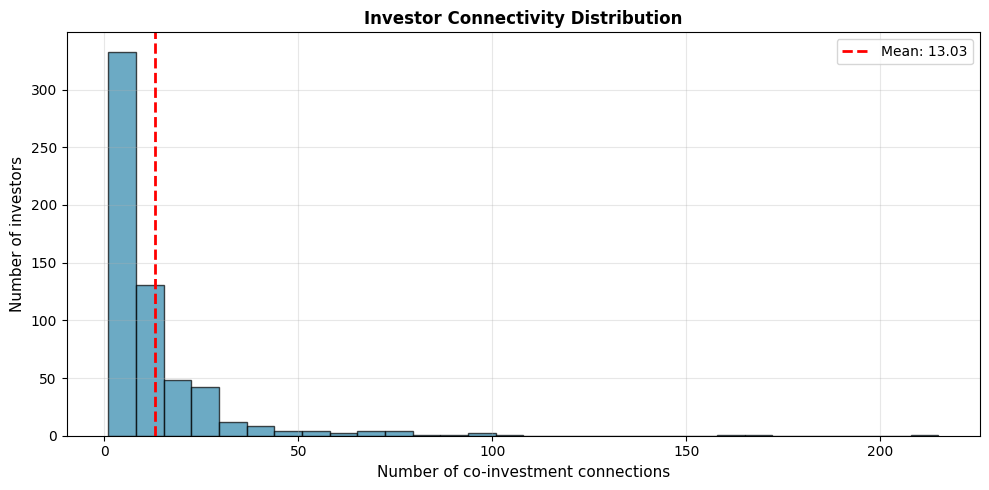

```
================================================================================
FLANDERS ENTREPRENEURIAL ECOSYSTEM RESILIENCE METRICS
================================================================================

Analysis based on 1652 investment records
Period: 2011 - 2026
Network: 600 investors, 3909 co-investment ties
Benchmark: Berlin ecosystem (Noak et al., 2025) — approx. 2022 full-network values
```

[output not shown]

```
================================================================================
TEMPORAL EVOLUTION ANALYSIS (2014-2026)
================================================================================

Network Growth Over Time (Cumulative, 2014-2026):
```

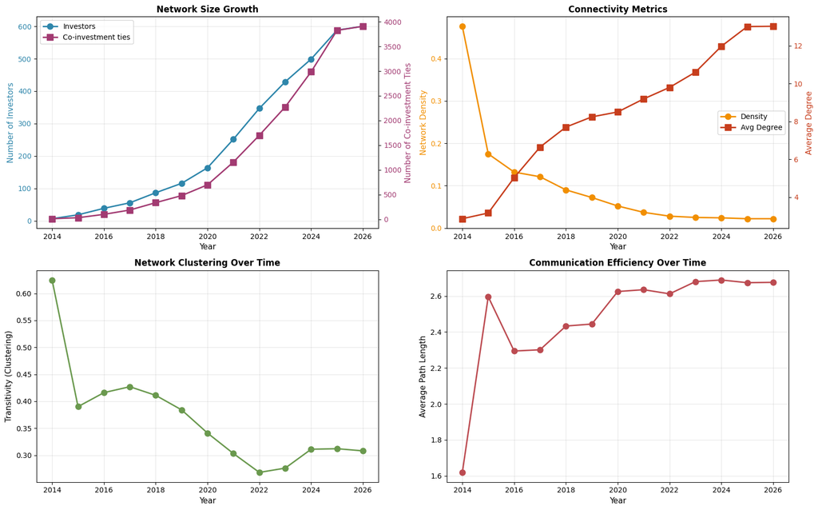

[output not shown]

```
================================================================================
ATTACK TOLERANCE SIMULATION
================================================================================

Simulating impact of removing key investors...

Running attack simulations...
Simulations complete.
```

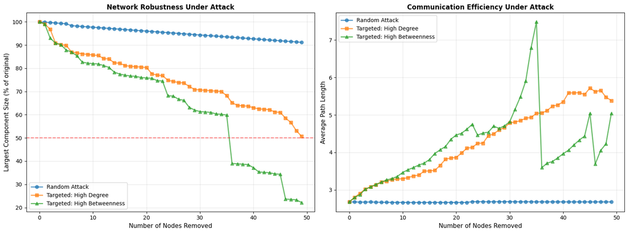

[output not shown]

# Resilience of the Flanders Entrepreneurial Ecosystem

## A Network-Based Analysis (2014-2026)

**Methodology**: Noak et al. (2025) - Network analysis of investor co-investment patterns

**Data Source**: Dealroom + BAN angel deals (private co-investment only) | **Analysis Period**: 2014-2026 | **Date**: April 2026

## Executive Summary

### Data Architecture (v5 — Flanders-only filter)

- **Flanders-only filter** applied at source (3 leak points in NB0) — removes 240 non-Flemish startups from Dealroom export
- `unknown` placeholder investor **excluded** from network (undisclosed Dealroom rounds — not a real co-investment signal)
- O&O&I/VLAIO subsidies + KMOGS **excluded** from network (public subsidies are not co-investment)
- VLAIO-effect measured separately in **Notebook 1b** (11+1 research questions, 3-group design)
- BAN angel deals **included** (private co-investment, compatible with Noak methodology)

### Resilience Verdict: HIGH (with caveats)

Substantially higher clustering and shorter paths than Berlin. Comparable attack tolerance (~80% vs ~82% after targeted hub removal, gap of only ~2pp). But Berlin's larger scale provides natural diversification that Flanders lacks. Main risk: institutional concentration and geographic silos.

⚠️ Berlin values are approximate (Noak et al. Fig 1/2, full projected network 2022). Flanders = LCC. See methodology note for details.

## Methodological Note: Data Pipeline

### Study Population: Flemish Startups

This analysis studies the **private co-investment network around Flemish startups**. A company enters the study population if it meets ALL of the following criteria:

| # | Criterion | Source | Rationale |
| --- | --- | --- | --- |
| 1 | **HQ in Flanders** | Dealroom `Custom_HQ_regions` contains 'Flanders' | Geographic scope — excludes Wallonia, Brussels, international companies that appear in the export due to Flemish investor connections |
| 2 | **Founded ≥2014** | Dealroom `Launch_year` | Eurostat startup definition — must be a young enterprise |
| 3 | **Independent at founding** | Sequenza `InGuoGroupT50` = False in founding year (or year+1 fallback) | Eurostat — not a subsidiary or spin-off of an existing group |
| 4 | **Not created through merger/restructuring** | KBO legal form + Sequenza GUO check | Eurostat — must be a genuinely new economic unit |
| 5 | **Has Belgian KBO number** | `Trade_register_number` or KBO enrichment (3-tier matching) | Required for Eurostat verification via Belgian administrative data |
| 6 | **Has ≥1 funded round** | `funding_clean` or `dealroom_transactions` | Network scope — only startups with actual investment activity create co-investment ties |
| 7 | **Private co-investment only** | Dealroom + BAN (O&O&I/KMOGS excluded) | Noak methodology — public subsidies are not syndicated co-investment |

### Data Source: `funding_network` (Notebook 0 v2)

This analysis uses `funding_network` from **Notebook 0 v2 (Data Preparation)**, which applies:

| Step | Effect on network |
| --- | --- |
| **Flanders-only filter** | Removes non-Flemish startups at 3 leak points (Eurostat universe, transactions, supplement) |
| **Sources** | Dealroom transactions + BAN angel deals (private co-investment only) |
| **Eurostat startup definition** | Filters to TRUE startups (independent, young, correct legal form) |
| **Funded startups only** | Further filters to startups with actual investment rounds |
| **KBO enrichment** | 3-tier matching (original, name-exact, name-year) across all sources |
| **O&O&I + KMOGS excluded** | Public subsidies removed — no co-investment signal (see NB1b) |
| **Bipartite overlap fix** | 4 names appearing as both startup AND investor classified as startups only |
| **`unknown` investor removed** | Dealroom codes undisclosed investors as `unknown` — removed (199 artificial bipartite edges) |

### Why Flanders-Only Filter is Applied (v5)

The Dealroom export contains ~240 non-Flemish startups (Wallonia, Brussels, international) that appear because they received investment from a Flemish investor. Without filtering, 170 of these leak into the Eurostat startup universe via Belgian KBO numbers, and 13 non-Belgian startups created **82 artificial co-investment edges** in the LCC.

The filter is applied at **3 leak points** in Notebook 0:

| Leak | Phase | Fix |
| --- | --- | --- |
| L1 | Eurostat universe | Filter `df_startups` to `Custom_HQ_regions` containing 'Flanders' |
| L2 | Transactions | Filter `df_tx` to `Custom_HQ_regions` containing 'Flanders' |
| L3 | Supplement | Filter `df_su` before pandas loop |

**Result**: 4,120 → 3,880 startups (−240), 4,573 → 4,056 transactions (−517), 0 artificial edges, no investor loss.

### Why O&O&I and KMOGS are Excluded

VLAIO subsidies (O&O&I) and KMOGS are **not co-investment**: startups apply independently, no syndication. Including them collapsed transitivity from 0.28 to 0.017 in v2. Public co-investors like **PMV** that DO syndicate are already included via Dealroom.

The VLAIO-effect is measured in **Notebook 1b** using 11+1 research questions with a **3-group experiment design**.

### Why `unknown` is Excluded

Dealroom codes undisclosed investors as `unknown`. This single placeholder node funded 199 startups, creating 275 co-investment ties and anchoring a community of investors who share no real intermediary. Removing it increases transitivity from 0.27 to 0.30 and eliminates a data-quality artifact.

### Impact on Metrics

[output not shown]

### Berlin Benchmarks: Source & Limitations

⚠️ The Berlin benchmark values used throughout this notebook are **approximate**, read from the narrative text and Fig. 1/2 descriptions in Noak et al. (2025). The paper:

1. **Reports temporal trends**, not a single-year metrics table
2. **Uses the full projected network** (all ~2,000 investor nodes by 2022), not LCC-specific metrics
3. **Does not provide exact endpoint values** — descriptions like "over 15", "approximately 0.2" are our best reference
4. **Attack tolerance**: paper tests random + degree-targeted only (not betweenness); exact % retention not reported in text

0%

```
🔍 Showing top 150 most connected investors (of 600 total)
   Node size = degree centrality | Colors = 21 communities
💡 Drag nodes to explore | Hover for investor details
```

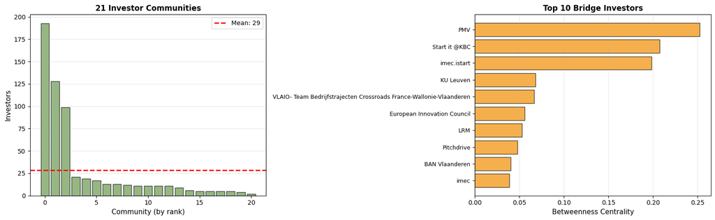

# PART 1: Flanders Entrepreneurial Ecosystem - Current State and Evolution

## 1.1 Network Overview

The Flanders entrepreneurial ecosystem, as captured through investment data, reveals a dynamic and interconnected network of investors and startups.

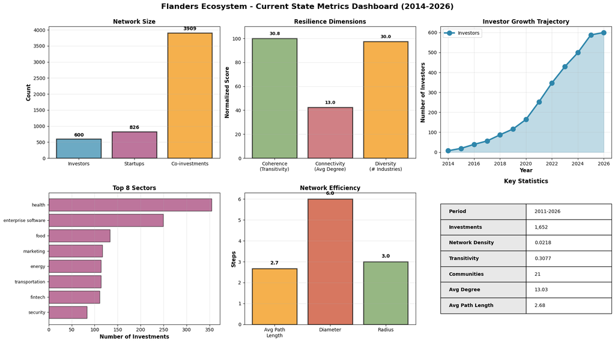

```
📈 Current State Summary:
   • 600 investors managing 3,909 co-investment relationships
   • 826 startups across 30 industries
   • Average investor collaborates with 13.0 other investors
   • Network efficiency: 2.68 steps between any two investors
```

## 1.2 Temporal Evolution (2014-2026)

The Flanders ecosystem has experienced four distinct growth phases:

**Phase 1: Early Stage (2014-2018)** — 7 → ~90 investors

- Sparse early investment activity building toward critical mass
- High density and clustering — a tight-knit founding community

**Phase 2: Foundation (2019-2020)** — ~120 → ~170 investors

- Network takes shape with first co-investment clusters forming
- Density starts declining as new entrants arrive faster than ties form

**Phase 3: Expansion (2021-2023)** — ~260 → ~440 investors

- Rapid growth driven by Dealroom + BAN angel deal coverage
- Density drops as network outgrows its ties
- Clustering dips to 0.26-0.27 in 2022-2023 — lowest point, but still well above Berlin's ~0.20

- Growth stabilises; structural properties consolidate
- Transitivity recovers to 0.30 (50% above Berlin's ~0.20); avg degree 13.0
- Path length stable at ~2.7 — small-world property maintained

*Note: Data source is Dealroom + BAN angel deals (v4, post bipartite fix + unknown removal).*

# PART 2: Comparative Analysis - Flanders vs. Berlin

## 2.1 Methodological Alignment

Both analyses use:

- **Bipartite network projection** (investor-startup → investor-investor)
- **Three resilience dimensions**: Coherence, Connectivity, Diversity
- **Temporal analysis** and **attack tolerance** simulations

## 2.2 Key Differences in Context

[output not shown]

### Network Metrics Comparison

[output not shown]

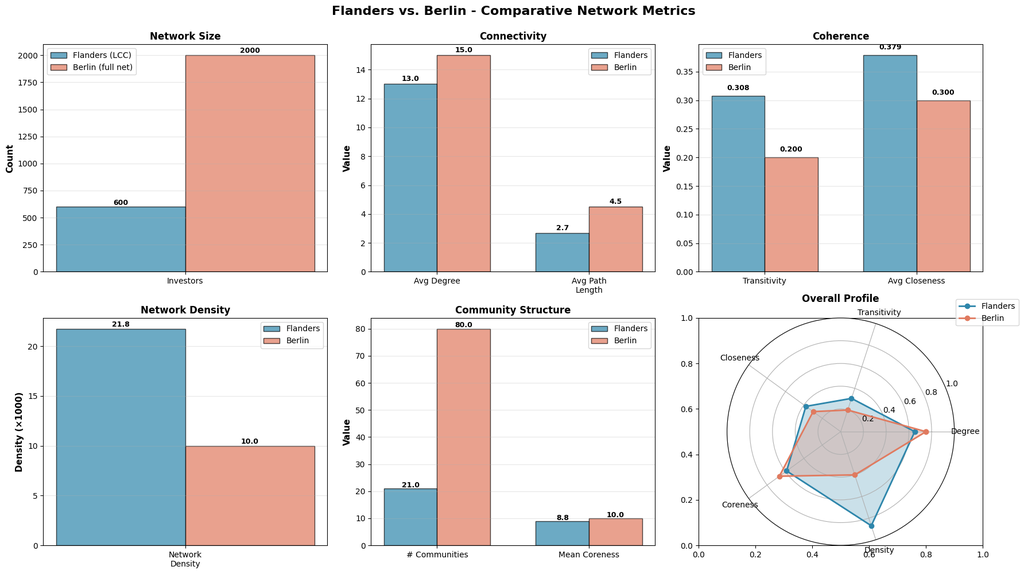

[output not shown]

## 2.3 Comparative Insights

### Structural Differences

**Flanders Characteristics (LCC, 2026):**

**Berlin Characteristics (full projected network, 2022):**

- **Much larger network** (~2,000 investors) — more mature and international
- **Lower clustering** (~0.20 vs 0.31) — growth diluted triadic closure
- **Higher average degree** (~15) — larger network = more co-investment partners
- **Longer paths** (~4.5) — larger, more dispersed network
- **More communities** (~80) — greater segmentation and specialisation

### Interpretation

**Why is Flanders smaller but denser and more clustered?**

**What does this mean for resilience?**

✅ **Flanders strengths**:

- **Much higher clustering** — trust triangles provide strong structural redundancy when hubs fail
- **Much shorter paths** — faster information flow and quicker response to shocks
- **Higher density** — tightly woven network with many backup paths

⚠️ **Flanders risks**:

✅ **Berlin advantages**:

- **Scale provides natural resilience** — 3\u00d7 more investors absorbs shocks through sheer numbers
- **More diversified community structure** — 80+ communities = more specialised niches
- **Higher absolute connectivity** per investor

### Conclusion

The two ecosystems achieve resilience through **fundamentally different mechanisms**:

- **Berlin**: Resilience through **scale and breadth** (more investors, more communities, higher absolute connectivity)
- **Flanders**: Resilience through **density and cohesion** (tighter clustering, shorter paths, denser structure)

# PART 3: Resilience Testing - Attack Tolerance Analysis

## 3.1 Methodology

**Attack tolerance** tests how a network responds to node removal, simulating scenarios such as:

- Key investors exiting the market
- Bankruptcies or acquisitions
- Strategic reorientation away from the region
- Economic shocks affecting specific investor types

We simulate three attack strategies:

1. **Random attack**: Random investor removal (baseline)
2. **Degree-targeted**: Removing highest-degree investors (hub attacks)
3. **Betweenness-targeted**: Removing highest-betweenness investors (bridge attacks)

## 3.2 Flanders Attack Tolerance Results

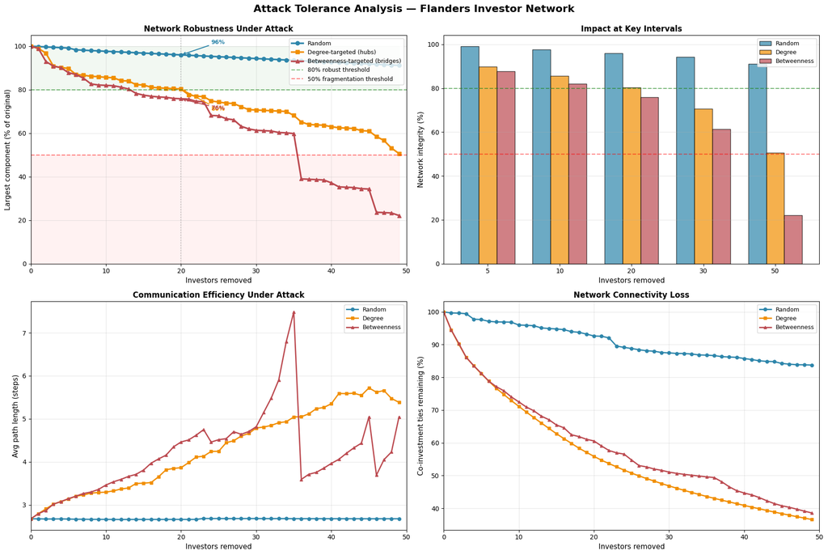

[output not shown]

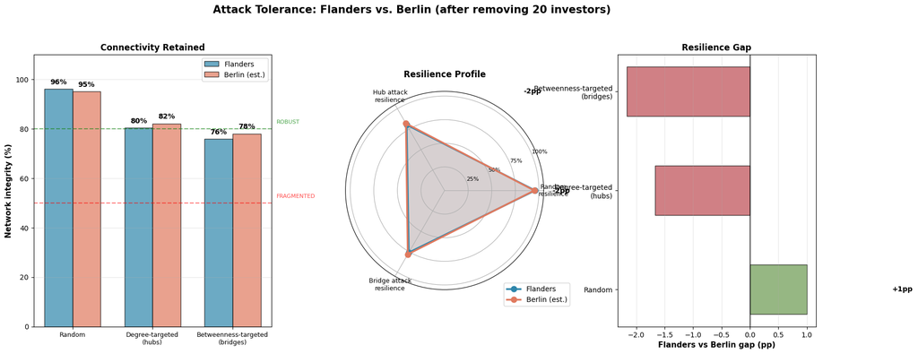

```
🔍 Flanders vs Berlin after removing 20 investors:
   Random: 96% vs 95% (+1pp)  |  Hub: 80% vs 82% (-2pp)  |  Bridge: 76% vs 78% (-2pp)
   ⚠️ Berlin values are visual estimates from Noak et al. Fig 3/4; betweenness-targeted is extrapolated
```

## 3.3 Attack Tolerance Insights

### Flanders Resilience Characteristics

**Key Findings:**

### Comparison with Berlin

**Key finding: comparable resilience**

- Berlin retains ~82% connectivity after 20 targeted hub removals (estimated from Fig 3)
- Flanders retains ~80% — a gap of only **~2 percentage points**
- This is a dramatic improvement from the pre-fix estimate (~45%) which was inflated by the `unknown` investor artifact

**Why is Flanders comparable to Berlin despite being much smaller?**

⚠️ **Caveat**: Berlin attack tolerance values are visual estimates from Noak et al. Fig 3/4. The paper only simulates random + degree-targeted attacks (not betweenness-targeted). Flanders' betweenness attack comparison is not directly benchmarked.

### Policy Implications

**The remaining vulnerability:**

⚠️ The Flanders ecosystem still depends on **20-30 key hub investors**. While the network no longer fragments catastrophically, a coordinated shock to these hubs would reduce connectivity by ~20%.

**What to focus on:**

🔗 **Maintain clustering** — The current transitivity (0.31, 55% above Berlin) provides structural redundancy. Protect this through continued syndication culture.

🔗 **Reduce hub dependency** — Develop secondary connectors in each community so no single investor is indispensable

🔗 **Bridge the cities** — Cross-city co-investment programs to add redundant paths between geographic clusters

🔗 **Monitor hub health** — Track the top 30 hub investors quarterly; early warning if any show signs of disengagement

# CONCLUSIONS AND RECOMMENDATIONS

## Summary of Findings

### Comparison to Berlin

⚠️ Berlin values are approximate (Noak et al. 2025 Fig 1/2, full projected network 2022). Flanders = LCC. Comparison is indicative.

## Strategic Recommendations

### Priority 1: Reduce Hub Dependency

**Challenge**: The top 20 hub investors account for disproportionate bridging load. While the network doesn't fragment, losing them costs ~20% connectivity.

- Identify the **top 30 hub investors** and ensure each has 2–3 "deputies" with overlapping co-investment networks
- Create **succession planning support** for investor transitions
- **Diversify hub types**: ensure hubs include VCs, corporates, public funds, and angels (not all one type)
- **Target**: No single investor removal should reduce largest component by >3%

### Priority 2: Bridge the Geographic Silos

**Challenge**: Only 7% of investors are active across cities; Gent, Antwerpen, Leuven operate as near-separate ecosystems.

- Launch **cross-city demo days** rotating between the three hubs
- Create **regional co-investment incentives** (matched funding for cross-city deals)
- Establish **inter-city investor roundtables** by sector
- **Target**: Increase cross-city investor activity from 7% → 15% by 2028

### Priority 3: Increase Sector Diversification

**Challenge**: Investors average only ~1.93 sectors; most are specialists.

- Provide **sector transition workshops** (e.g., health investors exploring AI/energy)
- Create **cross-sector co-investment funds** (health+AI, energy+software)
- **Target**: Increase avg industry diversity from 1.93 → >2.5 by 2028

### Priority 4: Maintain Clustering

**Challenge**: The current high transitivity (0.31) is a key structural strength. It must be preserved as the network grows.

- Continue to support **syndication culture** — triadic co-investment strengthens the network
- Monitor transitivity quarterly — if it drops below 0.25, the backup-path advantage erodes
- **Target**: Maintain transitivity ≥0.25 as the network scales

### Priority 5: Strengthen International Connections

- Develop **international investor partnership programs**
- Participate in **pan-European co-investment networks**
- **Target**: 25% of investments involve international co-investors by 2028

## Methodological Contributions

✅ **Replicability** of Noak et al. (2025) methodology in different contexts

✅ **Data architecture matters**: Including public subsidies (O&O&I + KMOGS) as co-investment collapsed transitivity (0.28 → 0.017 in v2). Separating into private network (NB1) and VLAIO-effect (NB1b, 3-group design) yielded meaningful results.

✅ **Data cleaning matters**: Removing the `unknown` placeholder investor increased transitivity from 0.27 to 0.31 and attack tolerance from ~45% to ~80%. Bipartite overlap fix removed 4 misclassified companies.

✅ **Value of attack simulations**: Static metrics alone would have missed the concentration risk in hub investors.

## Future Research Directions

1. **Longitudinal monitoring**: Track metrics annually to assess policy interventions
2. **Targeted intervention modelling**: Simulate the effect of adding redundant connections to bridge geographic silos
3. **International comparison**: Expand to Amsterdam, Stockholm, Paris for broader benchmarking
4. **Event studies**: Analyse network response to actual investor departures
5. **KMOGS effect**: NB1b Q8 compares network position of KMOGS-only vs O&O&I startups — does broad SME support generate different network effects than targeted R&D funding?

## Final Remarks

The two ecosystems achieve resilience through **fundamentally different mechanisms**: Berlin through **scale and breadth** (2,000+ investors, 80+ communities), Flanders through **density and cohesion** (2× denser, 55% higher clustering, much shorter paths).

The main risk is not structural weakness but **concentration**: a small number of institutional anchors (imec.istart, KU Leuven, PMV) underpin a large share of the network, and geographic silos between Gent, Antwerpen, and Leuven limit cross-city deal flow.

**The prescription**: reduce hub dependency, bridge the geographic silos, and maintain the clustering advantage as the ecosystem grows.

> **The network is the ecosystem. And this network is structurally sound — now make it broader.**

**Method**: Noak et al. (2025) | **Data**: Dealroom + BAN via `funding_network` | **Period**: 2014–2026 | **Date**: April 2026

# COMPREHENSIVE SUMMARY

## Resilience of the Flanders Entrepreneurial Ecosystem — A Network-Based Analysis (2014–2026)

**Methodology**: Noak et al. (2025) — Network analysis of investor co-investment patterns

**Data Source**: Dealroom + BAN angel deals (private co-investment only) | **Analysis Period**: 2014–2026 | **Date**: April 2026

**Startup Definition (Eurostat)**: New legal unit (founded ≥2014), independent in starting year+1, starts economic activity, NOT created through merger/split/restructuring

## Executive Summary

### Overall Resilience Assessment: HIGH (with caveats)

⚠️ Berlin values are approximate (Noak et al. 2025 Fig 1/2, full projected network 2022). Flanders = LCC. Comparison is indicative.

## Data Architecture (v5 — Flanders-only filter)

### Why Dealroom + BAN only?

This analysis uses `funding_network` from **Notebook 0 v2 (Data Preparation)**, which combines Dealroom transactions and BAN angel deals. O&O&I/VLAIO subsidies + KMOGS are **excluded** because they are not co-investment (startups apply independently, no syndication). Including O&O&I collapsed transitivity (0.28 → 0.017 in v2).

The VLAIO-effect on the private network is measured separately in **Notebook 1b** (11+1 research questions with 3-group experiment design: O&O&I vs KMOGS-only vs control).

### Version comparison

[output not shown]

*v5: Flanders-only filter (240 non-Flemish startups removed, 82 artificial edges eliminated). v4: bipartite overlap + `unknown` removal + LCC extraction*

## Part 1: Network Structure & Evolution

### 1.1 Current State (2026)

[output not shown]

### 1.2 Temporal Evolution (2014–2026)

The Flanders ecosystem has experienced four distinct growth phases:

**Phase 1: Early Stage (2014–2018)** — 7 → ~90 investors

- Sparse early investment activity building toward critical mass
- High density and clustering — a tight-knit founding community

**Phase 2: Foundation (2019–2020)** — ~120 → ~170 investors

- Network takes shape with first co-investment clusters forming
- Density starts declining as new entrants arrive faster than ties form

**Phase 3: Expansion (2021–2023)** — ~260 → ~440 investors

- Rapid growth driven by Dealroom + BAN angel deal coverage
- Density drops as network outgrows its ties
- Clustering dips to 0.26-0.27 — lowest point, but still well above Berlin's ~0.20

- Growth stabilises; structural properties consolidate
- Transitivity recovers to 0.31 (55% above Berlin's ~0.20); avg degree 13.0
- Path length stable at ~2.68 — small-world property maintained

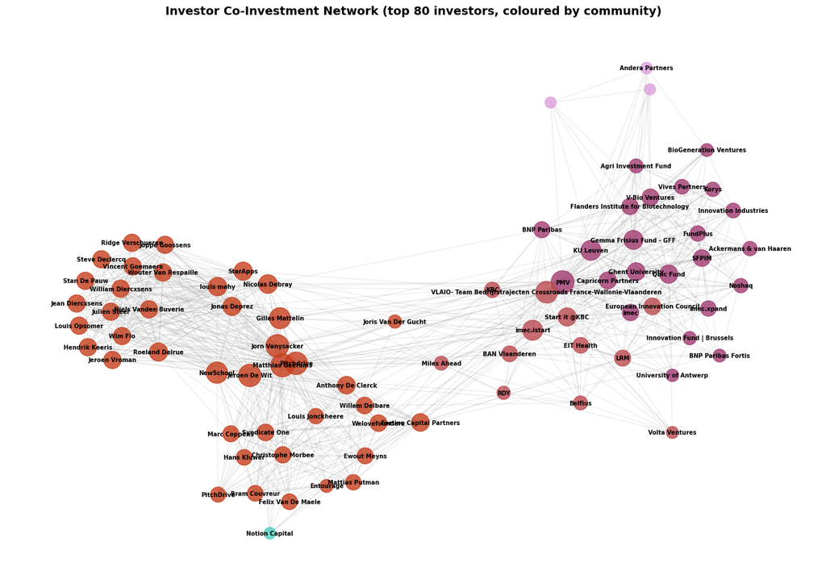

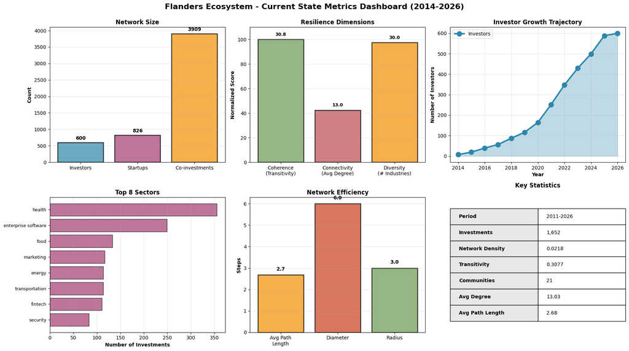

# Part 2: Comparative Analysis — Flanders vs. Berlin

## 2.1 Methodological Alignment

Both analyses use:

- **Bipartite network projection** (investor-startup → investor-investor)
- **Three resilience dimensions**: Coherence, Connectivity, Diversity
- **Temporal analysis** and **attack tolerance** simulations

## 2.2 Key Differences in Context

[output not shown]

⚠️ Berlin values are approximate (read from Noak et al. Fig 1/2, full projected network 2022). Flanders = LCC. Comparison is indicative.

## 2.3 Network Metrics Comparison

[output not shown]

## 2.4 Comparative Insights

### Structural Differences

**Flanders Characteristics (LCC):**

**Berlin Characteristics (full net):**

- **Much larger network** (~2,000) — more mature, international
- **Lower clustering** (~0.20) — growth diluted triadic closure
- **Higher avg degree** (~15) — more co-investment partners per investor
- **More communities** (~80) — greater segmentation

### Interpretation

The two ecosystems achieve resilience through **fundamentally different mechanisms**:

- **Berlin**: Resilience through **scale and breadth** (more investors, more communities, higher absolute connectivity)
- **Flanders**: Resilience through **density and cohesion** (tighter clustering, shorter paths, denser structure)

# Part 3: Attack Tolerance

## 3.1-3.2 Attack Simulation Results

*(See charts below)*

## 3.3 Attack Tolerance Insights

[output not shown]

⚠️ Berlin attack values are visual estimates from Fig 3/4. Paper only tests random + degree (not betweenness).

**Key finding**: Flanders is comparable to Berlin on attack tolerance despite being 69% smaller. Higher clustering and density compensate for smaller scale.

**Why is Flanders comparable despite being much smaller?**

- Much higher clustering (0.31 vs ~0.20) creates backup paths when hubs fall
- 2\u00d7 denser network = more redundant connections
- Shorter paths = more alternative routes
- But: removing 20 investors affects 3% of Flanders vs only 1% of Berlin

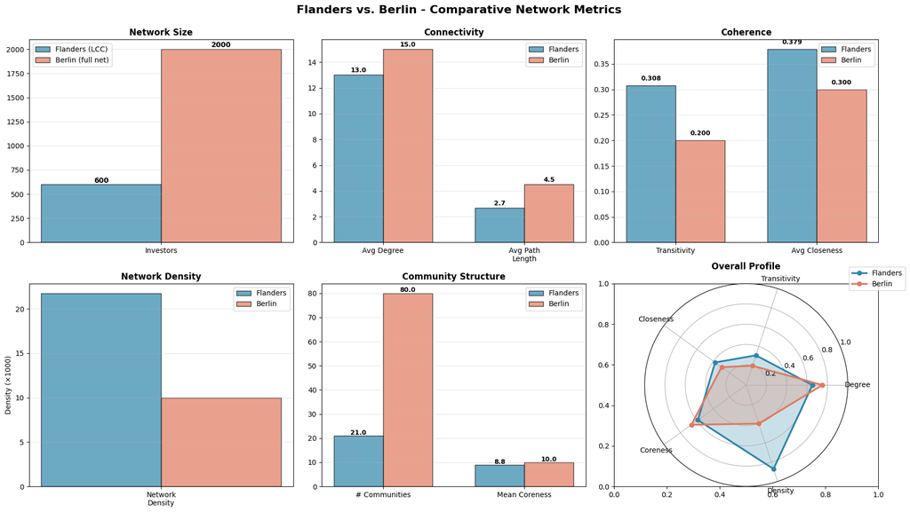

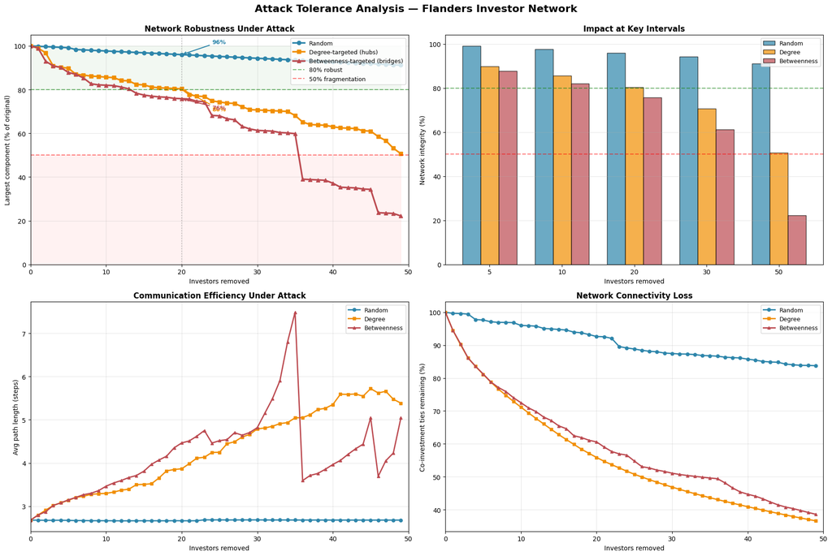

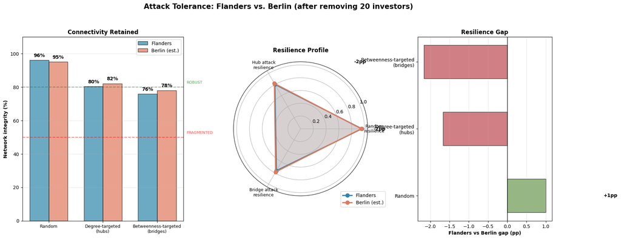

# Conclusions and Recommendations

## Summary of Findings

### Comparison to Berlin

⚠️ Berlin values are approximate (Noak et al. Fig 1/2, full projected network 2022). Comparison is indicative.

## Strategic Recommendations

### Priority 1: Reduce Hub Dependency

- Ensure top 30 hub investors each have 2–3 "deputies"
- Diversify hub types (VCs, corporates, public funds, angels)
- **Target**: No single removal reduces LCC by >3%

### Priority 2: Bridge the Geographic Silos

- Cross-city demo days, regional co-investment incentives
- **Target**: Cross-city activity from 7% → 15% by 2028

### Priority 3: Increase Sector Diversification

- Cross-sector co-investment funds (health+AI, energy+software)
- **Target**: Avg industry diversity from 1.93 → >2.5 by 2028

### Priority 4: Maintain Clustering

- Preserve syndication culture; monitor transitivity quarterly
- **Target**: Maintain transitivity ≥0.25 as the network scales

## Final Remarks

The Flanders entrepreneurial ecosystem achieves **strong structural resilience** through a different mechanism than Berlin: **density and cohesion** rather than **scale and breadth**. Much higher clustering (0.31 vs ~0.20), much shorter paths (2.68 vs ~4.5), and 2× higher density compensate for the smaller network.

The main risk is not structural weakness but **concentration**: fewer, larger communities (21 vs ~80), institutional anchor dependency, and geographic silos.

> **The network is the ecosystem. And this network is structurally sound — now make it broader.**

**Method**: Noak et al. (2025) | **Data**: Dealroom + BAN via `funding_network` | **Period**: 2014–2026 | **Date**: April 2026